# Cost per Click for Paid Search

- Show All Code
- Hide All Code
- View Source

# Introduction

For my entry in the [Posit 2024 table contest](https://posit.co/blog/announcing-the-2024-table-contest/), I wanted to visualize paid search data. Paid search is a type of advertising that refers to the text ads that float at the top of a search engine results page. My particular dataset had results for Google and Bing search and I was curious to see how this data might look after it’s been aggregated. I didn’t expect that the data would reveal anything super interesting so I saw the contest as more of an opportunity to practice my table building skills in R.

# Why I chose to use the GT package

I considered the [gt](https://gt.rstudio.com/) and [reactable](https://glin.github.io/reactable/) packages for the 2024 Posit table contest.

My preference would have been to use the `reactable` package because I like the ease with which you can dynamically group and aggregate table rows, but with reactable, you often need to get your hands dirty with javascript, which is more of a time suck for because it’s outside my comfort zone.

So, I developed my entry using `GT` which I enjoy because of its rich set of functions for creating html tables and extensive documentation.

# Inspirations

There are lots of tutorials and inspiration out there if you develop a table in R using `GT`. To get grounded, I watched a lot of youtube videos. Essentially, everything and anything that was brought up by the following [search query in youtube](https://www.youtube.com/results?search_query=r+gt).

# Final Table

```r
library(dplyr)
library(fontawesome)
library(gt)
library(gtExtras)
library(ggiraph)
library(ggplot2)
library(here)
library(stringr)
library(tidyr)



ps_cpc <- read.csv(here('data', 'paid_search_cost_per_click.csv'))
source(here("r", "my_tbl_theme.R"))

legend <- html('<i>Yes! But that&apos;s where your brand can find new customers</i><div class="align-legend"><pre style="display: inline;font-family: Arial, Verdana, sans-serif; font-size: 15px; text-align: right"><span style="background-color: #00A600;"
                       >        </span> = Low</pre> <pre style="display: inline;font-family: Arial, Verdana, sans-serif; font-size: 15px; text-align: right"><span style="background-color: #D69C4E;"
                       >        </span> = Med</pre> <pre style="display: inline;font-family: Arial, Verdana, sans-serif; font-size: 15px; text-align: right"><span style="background-color: brown;"
                       >        </span> = High</pre></div>')


ps_cpc_tbl <- gt(ps_cpc) |>
  tab_header(
    title = md("**Cost per click: Are non branded keywords more expensive?**"),
    # subtitle = md("*Yes! But that's where your brand can find new customers*")
    subtitle = legend
  ) |>
  tab_spanner(
    label = "Brand",
    columns = starts_with("b_")
  ) |>
  tab_spanner(
    label = "Non Brand",
    columns = starts_with("nb_")
  ) |>
  cols_hide(
    columns = c(publisher, device)
  ) |>
  cols_align(
    columns = c(country, publisher, channel_icon, device, device_icon),
    align = "left"
  ) |>
  cols_align(
    columns = contains("_"),
    align = "center"
  ) |>
  cols_add(
    whitespace = "",
    .after = "b_sep"
  ) |>
  cols_merge(
    columns = c(channel_icon, device_icon),
    pattern = "{1} {2}"
  ) |>
  cols_merge(
    columns = c(country, country_name),
    pattern = "{1} {2}"
  ) |>
  cols_label(
    country ~ "country",
    channel_icon ~ "delivery",
    whitespace ~ md("&emsp;")
  ) |>
  cols_width(
    country ~ px(160),
    channel_icon ~ px(100),
    whitespace ~ px(15),
    everything() ~ px(80)
  ) |>
  cols_label_with(
    columns = where(is.numeric),
    fn = function(x) {
      if_else(str_detect(x, "^b_|^nb_"), str_remove(x, "b_|nb_"), x)
    }
  ) |>
  fmt_currency(
    columns = contains("_"),
    decimals = 2,
    currency = "USD"
  ) |>
  fmt_flag(
    columns = country,
    height = "1.2em"
  ) |>
  fmt_icon(
    columns = c(channel_icon, device_icon),
    fill_color = "#8C8F93"
  ) |>
  sub_values(
    columns = contains("_"),
    fn = function(x) if_else(is.nan(x) | is.na(x), TRUE, FALSE),
    replacement = "-"
  ) |>
  data_color(
    columns = where(is.numeric),
    palette = c(
      "#00A600", "#E6E600", "#E8C32E", "#D69C4E", "#Dc863B", "sienna", "sienna4",
      "tomato4", "brown"
    ),
    domain = c(0, 7),
    na_color = "#FFFFFF",
    apply_to = "fill"
  ) |>
  gt_add_divider(
    columns = b_may,
    sides = "left",
    color = "#D3D3D3",
    style = "solid",
    weight = px(2),
    include_labels = FALSE
  ) |>
  tab_style(
    style = cell_text(
      align = "left"
    ),
    locations = list(
      cells_body(columns = c(channel_icon, device_icon)),
      cells_column_labels(columns = c(channel_icon, device_icon))
    )
  ) |>
  opt_table_font(
    font = c("Arial", default_fonts())
  ) |>
  tab_style(
    style = list(
      cell_borders(
        color = "#FFFFFF",
        weight = px(0))
    ),
    locations = list(cells_body(
      columns = whitespace
    ), cells_column_labels(
      columns = whitespace)
    )
  ) |>
  tab_footnote(
    footnote = html(paste0(fa(name = "microsoft", fill = "#8C8F93"), ' = Bing Search, '),
                    paste0(fa(name = "google", fill = "#8C8F93"), ' = Google Search, '),
                    paste0(fa(name = "desktop", fill = "#8C8F93"), ' = Desktop, '),
                    paste0(fa(name = "mobile", fill = "#8C8F93"), ' = Mobile')),
    locations = cells_column_labels(columns = channel_icon)
  ) |>
  opt_css(
    css = '
     .align-legend {
      text-align: right;
    }
    '
  ) |>
  my_tbl_theme()
```

**Cost per click: Are non branded keywords more expensive?**

*Yes! But that's where your brand can find new customers*

```
         = Low
```

```
         = Med
```

```
         = High
```

country

delivery<sup>1</sup>

Brand

Non Brand

may

jun

jul

aug

sep

may

jun

jul

aug

sep

Australia

$0.47

$0.77

$0.55

$0.47

$0.37

$2.07

$2.25

$2.40

$1.50

-

Australia

-

-

-

-

-

$2.07

-

-

-

-

Canada

$1.06

$0.83

$1.08

$0.67

$0.65

$2.01

$2.14

$3.27

$1.82

-

United Kingdom

$0.23

$0.43

$0.40

$0.54

$1.37

$1.67

$1.78

$2.19

$1.72

-

United Kingdom

-

-

-

-

-

$1.67

-

-

-

-

Ireland

$0.35

$0.52

$0.24

$0.38

$0.45

$1.28

-

-

-

-

Ireland

-

-

-

-

-

$1.28

-

-

-

-

New Zealand

$0.19

$2.02

$0.68

$0.48

$0.66

$2.36

-

-

-

-

New Zealand

-

-

-

-

-

$2.36

-

-

-

-

United States

$0.80

$0.52

$0.59

$0.96

$1.13

$2.99

$2.43

$3.61

$1.74

-

United States

-

-

-

-

-

$2.99

-

-

-

-

South Africa

$0.78

-

$0.54

$0.51

$0.96

$1.96

-

-

-

-

Australia

$0.34

$0.47

$0.51

$0.80

$1.68

$3.65

$6.10

$4.90

$3.69

$3.64

Australia

$0.34

-

-

-

-

$3.65

-

-

-

-

Canada

$0.46

$0.62

$0.58

$0.42

$0.56

$3.34

$5.45

$3.75

$2.31

$1.71

Canada

$0.46

-

-

-

-

$3.34

-

-

-

-

Germany

$0.09

$0.18

$0.23

$0.19

$0.18

$3.35

-

-

-

-

United Kingdom

$0.43

$0.66

$0.66

$0.58

$2.11

$2.52

$5.37

$3.82

$2.41

$2.46

United Kingdom

$0.43

-

-

-

-

$2.52

-

-

-

-

Ireland

$0.28

$0.51

$0.38

$0.63

$0.54

$3.70

-

-

$1.36

$1.51

Ireland

-

-

-

-

-

$3.70

-

-

-

-

Netherlands

$0.15

-

-

$0.37

$0.82

$3.01

-

-

-

-

New Zealand

$0.19

$0.46

$0.37

$0.26

$0.84

$2.19

-

-

$1.49

$1.95

New Zealand

$0.19

-

-

-

-

$2.19

-

-

-

-

Philippines

$1.08

-

-

$0.56

$1.68

$1.43

-

-

-

-

Philippines

-

-

-

-

-

$1.43

-

-

-

-

Singapore

$0.08

-

-

$0.41

$0.46

$2.06

-

-

-

-

Singapore

-

-

-

-

-

$2.06

-

-

-

-

United States

$0.55

$0.63

$0.68

$0.57

$0.95

$3.00

$4.97

$3.63

$2.32

$4.20

United States

$0.55

-

-

-

-

$3.00

-

-

-

-

South Africa

$0.17

$0.24

$0.50

$0.27

$0.68

$2.64

-

-

$1.09

$1.21

South Africa

$0.17

-

-

-

-

$2.64

-

-

-

-

Austria

-

$0.07

$0.15

$0.09

$0.08

-

-

-

-

-

Brazil

-

$0.26

$0.06

$0.10

-

-

-

-

-

-

Switzerland

-

$0.24

$0.22

$0.18

$0.18

-

-

-

-

-

[figure not shown]

Spain

-

$0.07

$0.11

$0.06

$0.07

-

-

-

-

-

France

-

$0.18

$0.20

$0.27

$0.26

-

-

-

$1.01

$0.39

Italy

-

$0.13

$0.15

$0.11

$0.12

-

-

-

-

-

Mexico

-

$0.04

$0.13

$0.07

$0.10

-

-

-

$0.43

$0.31

Portugal

-

$0.14

$0.06

$0.01

$0.34

-

-

-

-

-

Argentina

-

-

-

-

$0.05

-

-

-

-

-

Chile

-

-

-

-

$0.09

-

-

-

-

-

Panama

-

-

-

-

$0.06

-

-

-

-

-

Peru

-

-

-

-

$0.03

-

-

-

-

-

<sup>1</sup> = Bing Search, = Google Search, = Desktop, = Mobile

# Color considerations

For the color scheme, I borrowed from [Grant Chalmer’s Twitter post](https://twitter.com/GrantChalmers/status/1774924163834335335). While the administration of a color palette in GT is straightforward, it was setting the bounds for the color palette that took more thinking.

In the particular case of my dataset, if I had more data, I would have wanted to study the distribution of cost per click over years rather than a few select months. That said, a few quick visualizations of the cost per click distribution in the data can be useful for understanding how you want to implement your color scale.

**Deciles**

```r
ps_cpc_narrow <- ps_cpc |>
  pivot_longer(b_may:nb_sep) |>
  mutate(decile = ntile(value, n = 10),
         value = round(value, digits = 2))

gg_point <- ggplot(data = ps_cpc_narrow) +
  geom_point_interactive(aes(x = decile, y = value, tooltip = sprintf(value, fmt = '$ %#.2f'))) +
  ylab("Cost per Click") +
  theme_minimal() +
  ggtitle("Distribution of cost per click broken down into deciles")

girafe(ggobj = gg_point)
```

[interactive chart not shown]

**Density**

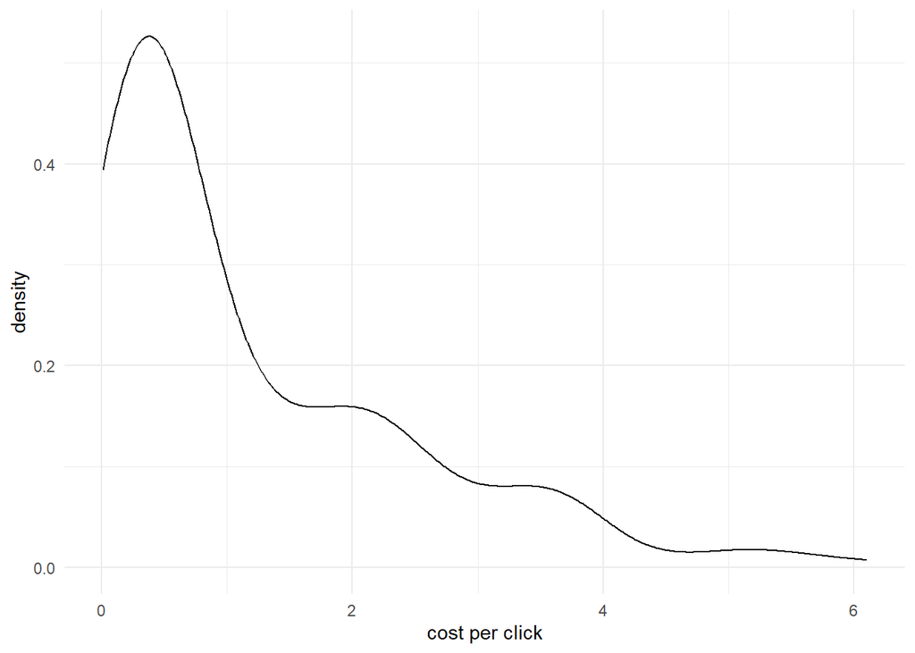

```r
ggplot(ps_cpc_narrow, aes(x = value)) +
  geom_density() +
  xlab("cost per click") +
  theme_minimal()
```

# Challenges in building table

**Merge columns** - I wanted to turn on the interactive html option for the table but I found that some features such as merging columns would break the table. As a result, I opted to leave the interactive html turned off. Generally speaking, I found the ihtml option to be sensitive in that it breaks easily. For me, the most useful interactive feature for my table would have been the table sort feature.

**Adding a color legend** - For my legend, I searched the Posit message boards and ended up modifying a snippet from [here](https://forum.posit.co/t/trying-to-add-legend-to-gt-table/172872).